# Assignment_4

Kight Pruszynski

2025-12-01

## INTRODUCTION

An equities analyst is studying the pharmaceutical industry to learn its structure using some basic financial measures. Financial data is gathered on 21 firms in the pharmaceutical industry, including the following variables: market capitalization (billions of dollars), beta, price/earnings ratio, return on equity, return on assets, asset turnover, leverage, estimated revenue growth, net profit margin, median recommendation (across major brokerages), location of firm’s headquarters, and stock exchange on which the firm is listed. In this assignment, I use k-Means clustering methods to cluster and evaluate these firms.

## PART A: Cluster 21 Firms

### Import Numerical Values from Pharmaceuticals.csv Dataset

Select only columns with numerical values.

```r
library(tidyverse) # data manipulation
library(factoextra) # clustering algorithms & visualization
library(ISLR)

set.seed(123)

pharma<-read.csv("Pharmaceuticals.csv") # load csv data
row.names(pharma)<-pharma[,1]
summary(pharma)
```

```
##     Symbol              Name             Market_Cap          Beta
##  Length:21          Length:21          Min.   :  0.41   Min.   :0.1800
##  Class :character   Class :character   1st Qu.:  6.30   1st Qu.:0.3500
##  Mode  :character   Mode  :character   Median : 48.19   Median :0.4600
##                                        Mean   : 57.65   Mean   :0.5257
##                                        3rd Qu.: 73.84   3rd Qu.:0.6500
##                                        Max.   :199.47   Max.   :1.1100
##     PE_Ratio          ROE            ROA        Asset_Turnover    Leverage
##  Min.   : 3.60   Min.   : 3.9   Min.   : 1.40   Min.   :0.3    Min.   :0.0000
##  1st Qu.:18.90   1st Qu.:14.9   1st Qu.: 5.70   1st Qu.:0.6    1st Qu.:0.1600
##  Median :21.50   Median :22.6   Median :11.20   Median :0.6    Median :0.3400
##  Mean   :25.46   Mean   :25.8   Mean   :10.51   Mean   :0.7    Mean   :0.5857
##  3rd Qu.:27.90   3rd Qu.:31.0   3rd Qu.:15.00   3rd Qu.:0.9    3rd Qu.:0.6000
##  Max.   :82.50   Max.   :62.9   Max.   :20.30   Max.   :1.1    Max.   :3.5100
##    Rev_Growth    Net_Profit_Margin Median_Recommendation   Location
##  Min.   :-3.17   Min.   : 2.6      Length:21             Length:21
##  1st Qu.: 6.38   1st Qu.:11.2      Class :character      Class :character
##  Median : 9.37   Median :16.1      Mode  :character      Mode  :character
##  Mean   :13.37   Mean   :15.7
##  3rd Qu.:21.87   3rd Qu.:21.1
##  Max.   :34.21   Max.   :25.5
##    Exchange
##  Length:21
##  Class :character
##  Mode  :character
##
##
##
```

```r
str(pharma) # identify numeric data for inclusion
```

```
## 'data.frame':    21 obs. of  14 variables:
##  $ Symbol               : chr  "ABT" "AGN" "AHM" "AZN" ...
##  $ Name                 : chr  "Abbott Laboratories" "Allergan, Inc." "Amersham plc" "AstraZeneca PLC" ...
##  $ Market_Cap           : num  68.44 7.58 6.3 67.63 47.16 ...
##  $ Beta                 : num  0.32 0.41 0.46 0.52 0.32 1.11 0.5 0.85 1.08 0.18 ...
##  $ PE_Ratio             : num  24.7 82.5 20.7 21.5 20.1 27.9 13.9 26 3.6 27.9 ...
##  $ ROE                  : num  26.4 12.9 14.9 27.4 21.8 3.9 34.8 24.1 15.1 31 ...
##  $ ROA                  : num  11.8 5.5 7.8 15.4 7.5 1.4 15.1 4.3 5.1 13.5 ...
##  $ Asset_Turnover       : num  0.7 0.9 0.9 0.9 0.6 0.6 0.9 0.6 0.3 0.6 ...
##  $ Leverage             : num  0.42 0.6 0.27 0 0.34 0 0.57 3.51 1.07 0.53 ...
##  $ Rev_Growth           : num  7.54 9.16 7.05 15 26.81 ...
##  $ Net_Profit_Margin    : num  16.1 5.5 11.2 18 12.9 2.6 20.6 7.5 13.3 23.4 ...
##  $ Median_Recommendation: chr  "Moderate Buy" "Moderate Buy" "Strong Buy" "Moderate Sell" ...
##  $ Location             : chr  "US" "CANADA" "UK" "UK" ...
##  $ Exchange             : chr  "NYSE" "NYSE" "NYSE" "NYSE" ...
```

```r
pharma<-pharma[,c(3:11)] # select only columns with numeric data (numeric variables)
summary(pharma)
```

```
##    Market_Cap          Beta           PE_Ratio          ROE
##  Min.   :  0.41   Min.   :0.1800   Min.   : 3.60   Min.   : 3.9
##  1st Qu.:  6.30   1st Qu.:0.3500   1st Qu.:18.90   1st Qu.:14.9
##  Median : 48.19   Median :0.4600   Median :21.50   Median :22.6
##  Mean   : 57.65   Mean   :0.5257   Mean   :25.46   Mean   :25.8
##  3rd Qu.: 73.84   3rd Qu.:0.6500   3rd Qu.:27.90   3rd Qu.:31.0
##  Max.   :199.47   Max.   :1.1100   Max.   :82.50   Max.   :62.9
##       ROA        Asset_Turnover    Leverage        Rev_Growth
##  Min.   : 1.40   Min.   :0.3    Min.   :0.0000   Min.   :-3.17
##  1st Qu.: 5.70   1st Qu.:0.6    1st Qu.:0.1600   1st Qu.: 6.38
##  Median :11.20   Median :0.6    Median :0.3400   Median : 9.37
##  Mean   :10.51   Mean   :0.7    Mean   :0.5857   Mean   :13.37
##  3rd Qu.:15.00   3rd Qu.:0.9    3rd Qu.:0.6000   3rd Qu.:21.87
##  Max.   :20.30   Max.   :1.1    Max.   :3.5100   Max.   :34.21
##  Net_Profit_Margin
##  Min.   : 2.6
##  1st Qu.:11.2
##  Median :16.1
##  Mean   :15.7
##  3rd Qu.:21.1
##  Max.   :25.5
```

```r
str(pharma)
```

```
## 'data.frame':    21 obs. of  9 variables:
##  $ Market_Cap       : num  68.44 7.58 6.3 67.63 47.16 ...
##  $ Beta             : num  0.32 0.41 0.46 0.52 0.32 1.11 0.5 0.85 1.08 0.18 ...
##  $ PE_Ratio         : num  24.7 82.5 20.7 21.5 20.1 27.9 13.9 26 3.6 27.9 ...
##  $ ROE              : num  26.4 12.9 14.9 27.4 21.8 3.9 34.8 24.1 15.1 31 ...
##  $ ROA              : num  11.8 5.5 7.8 15.4 7.5 1.4 15.1 4.3 5.1 13.5 ...
##  $ Asset_Turnover   : num  0.7 0.9 0.9 0.9 0.6 0.6 0.9 0.6 0.3 0.6 ...
##  $ Leverage         : num  0.42 0.6 0.27 0 0.34 0 0.57 3.51 1.07 0.53 ...
##  $ Rev_Growth       : num  7.54 9.16 7.05 15 26.81 ...
##  $ Net_Profit_Margin: num  16.1 5.5 11.2 18 12.9 2.6 20.6 7.5 13.3 23.4 ...
```

### Cluster the 21 Firms

First, I create a heat map. The heat map appears to show three distinct clusters: one purple cluster each on the left and right, and the red rectangle on the bottom left.

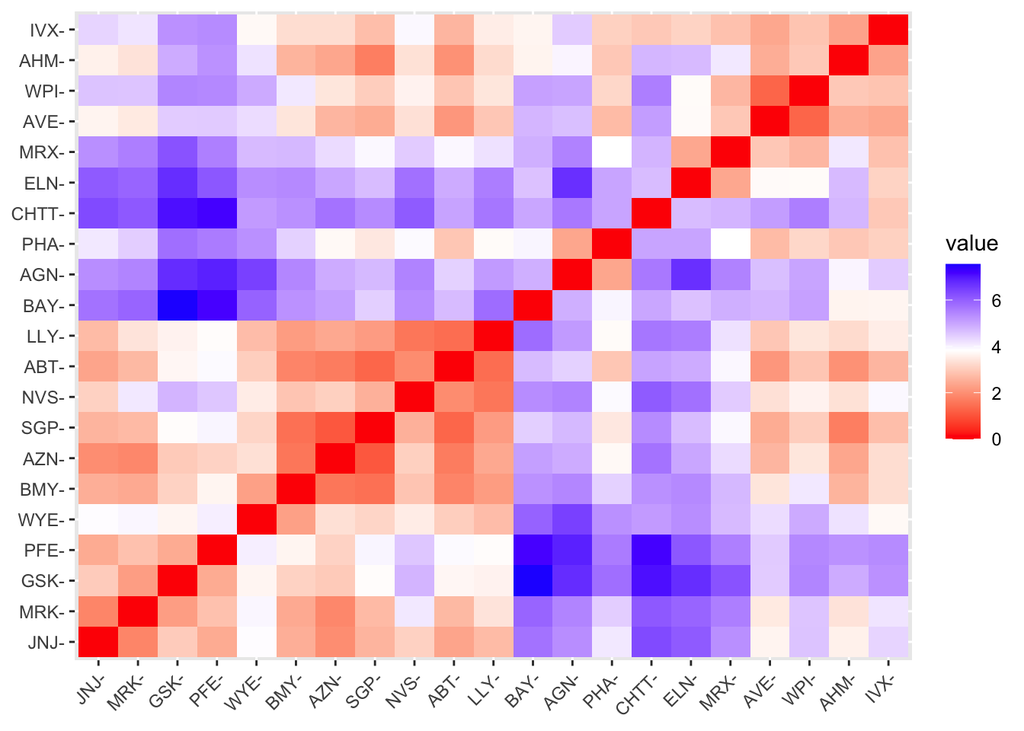

```r
pharma<-scale(pharma) # normalize data (z-Score)
distance<-get_dist(pharma) # determine distance
fviz_dist(distance) # visualize distance
```

### Run K-Means Algorithm; K = 3

Because I see three clusters in the heat map, I decide to try a K of 3 to start. The three clusters look distinct and meaningful. They are well separated, which suggests that there are notable differences between the clusters. Each cluster has enough firms to be meaningful and the centers suggest meaningful similarities between the firms in each cluster. As an analyst, I would be very curious to see what metrics the firms in each cluster have in common.

```r
k3 <- kmeans(pharma, centers=3, nstart=25)
k3$centers
```

```
##   Market_Cap       Beta   PE_Ratio        ROE        ROA Asset_Turnover
## 1 -0.6125361  0.2698666  1.3143935 -0.9609057 -1.0174553      0.2306328
## 2  0.6733825 -0.3586419 -0.2763512  0.6565978  0.8344159      0.4612656
## 3 -0.8261772  0.4775991 -0.3696184 -0.5631589 -0.8514589     -0.9994088
##     Leverage Rev_Growth Net_Profit_Margin
## 1 -0.3592866 -0.5757385        -1.3784169
## 2 -0.3331068 -0.2902163         0.6823310
## 3  0.8502201  0.9158889        -0.3319956
```

```r
k3$size
```

```
## [1]  4 11  6
```

```r
k3$cluster
```

```
##  ABT  AGN  AHM  AZN  AVE  BAY  BMY CHTT  ELN  LLY  GSK  IVX  JNJ  MRX  MRK  NVS
##    2    1    1    2    3    1    2    3    3    2    2    3    2    3    2    2
##  PFE  PHA  SGP  WPI  WYE
##    2    1    2    3    2
```

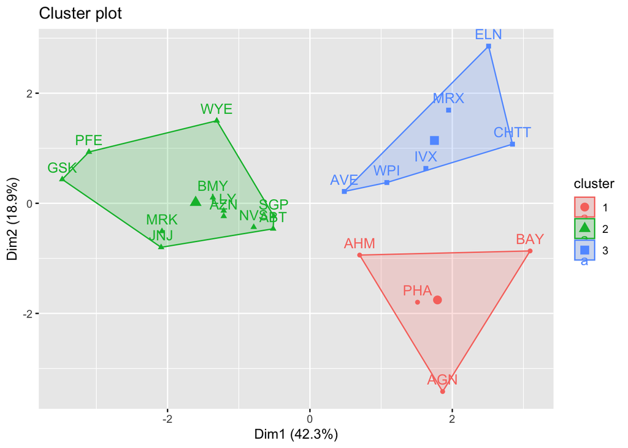

```r
fviz_cluster(k3, data=pharma)
```

### Run K-Means Algorithm; K = 2

K-Means clustering is somewhat subjective. We should try other near numbers of clusters to see how they look. I decide to try a K of two. Again, the space between the clusters is distinct and there are a lot of firms in each cluster. As an analyst, I would be curious to see what the differences are between these two groups of firms, but my instinct is that three clusters will give me more refined nuance than two.

```r
k2 <- kmeans(pharma, centers=2, nstart=25)
k2$centers
```

```
##   Market_Cap       Beta   PE_Ratio        ROE        ROA Asset_Turnover
## 1  0.6733825 -0.3586419 -0.2763512  0.6565978  0.8344159      0.4612656
## 2 -0.7407208  0.3945061  0.3039863 -0.7222576 -0.9178575     -0.5073922
##     Leverage Rev_Growth Net_Profit_Margin
## 1 -0.3331068 -0.2902163         0.6823310
## 2  0.3664175  0.3192379        -0.7505641
```

```r
k2$size
```

```
## [1] 11 10
```

```r
k2$cluster
```

```
##  ABT  AGN  AHM  AZN  AVE  BAY  BMY CHTT  ELN  LLY  GSK  IVX  JNJ  MRX  MRK  NVS
##    1    2    2    1    2    2    1    2    2    1    1    2    1    2    1    1
##  PFE  PHA  SGP  WPI  WYE
##    1    2    1    2    1
```

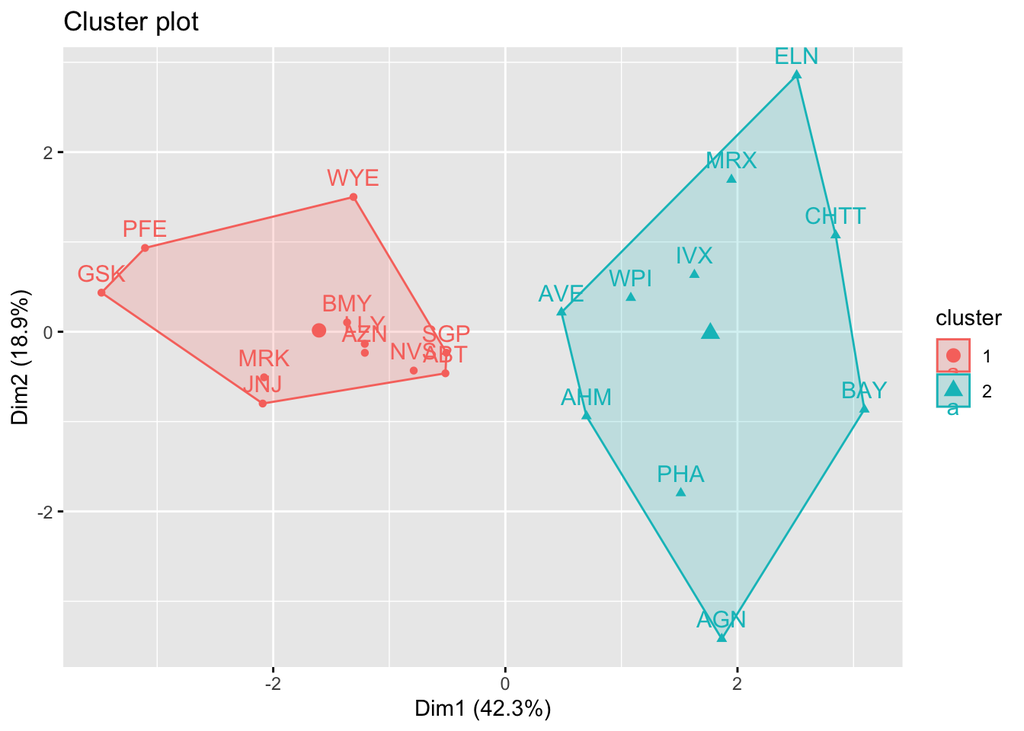

```r
fviz_cluster(k2, data=pharma)
```

### Run K-Means Algorithm; K = 4

I again try another K: four. Now the groups are getting pretty small. I might still be curious as an analyst to see what each cluster’s firms have in common with each other, or how they differ from the other firms, but I see that a lot of the firms are positioned on the borders of their clusters, which makes me think that the commonalities within each cluster aren’t as strong as in a K of two or three.

```r
k4 <- kmeans(pharma, centers=4, nstart=25)
k4$centers
```

```
##    Market_Cap       Beta   PE_Ratio        ROE        ROA Asset_Turnover
## 1 -0.03142211 -0.4360989 -0.3172485  0.1950459  0.4083915   1.729746e-01
## 2 -0.82617719  0.4775991 -0.3696184 -0.5631589 -0.8514589  -9.994088e-01
## 3  1.69558112 -0.1780563 -0.1984582  1.2349879  1.3503431   1.153164e+00
## 4 -0.52462814  0.4451409  1.8498439 -1.0404550 -1.1865838  -3.330669e-16
##     Leverage Rev_Growth Net_Profit_Margin
## 1 -0.2744931 -0.7041516         0.5569544
## 2  0.8502201  0.9158889        -0.3319956
## 3 -0.4680782  0.4671788         0.5912425
## 4 -0.3443544 -0.5769454        -1.6095439
```

```r
k4$size
```

```
## [1] 8 6 4 3
```

```r
k4$cluster
```

```
##  ABT  AGN  AHM  AZN  AVE  BAY  BMY CHTT  ELN  LLY  GSK  IVX  JNJ  MRX  MRK  NVS
##    1    4    1    1    2    4    1    2    2    1    3    2    3    2    3    1
##  PFE  PHA  SGP  WPI  WYE
##    3    4    1    2    1
```

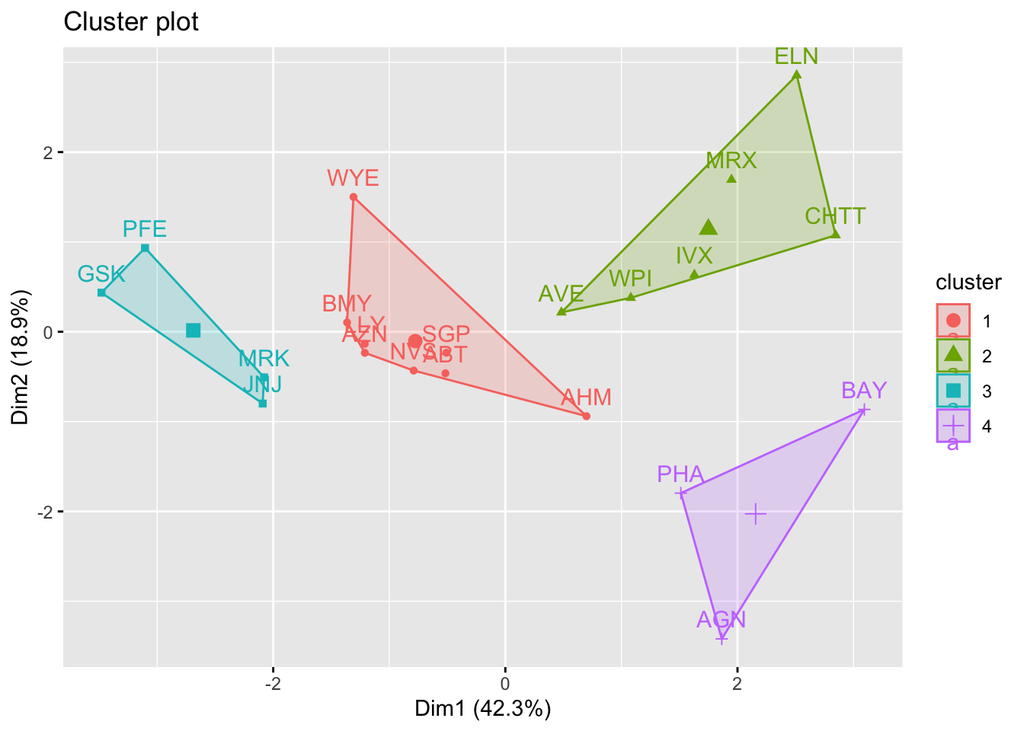

```r
fviz_cluster(k4, data=pharma)
```

### Run K-Means Algorithm; K = 5

```r
k5 <- kmeans(pharma, centers=5, nstart=25)
k5$centers
```

```
##    Market_Cap       Beta    PE_Ratio        ROE        ROA Asset_Turnover
## 1 -0.03142211 -0.4360989 -0.31724852  0.1950459  0.4083915      0.1729746
## 2 -0.87051511  1.3409869 -0.05284434 -0.6184015 -1.1928478     -0.4612656
## 3 -0.43925134 -0.4701800  2.70002464 -0.8349525 -0.9234951      0.2306328
## 4  1.69558112 -0.1780563 -0.19845823  1.2349879  1.3503431      1.1531640
## 5 -0.76022489  0.2796041 -0.47742380 -0.7438022 -0.8107428     -1.2684804
##      Leverage Rev_Growth Net_Profit_Margin
## 1 -0.27449312 -0.7041516       0.556954446
## 2  1.36644699 -0.6912914      -1.320000179
## 3 -0.14170336 -0.1168459      -1.416514761
## 4 -0.46807818  0.4671788       0.591242521
## 5  0.06308085  1.5180158      -0.006893899
```

```r
k5$size
```

```
## [1] 8 3 2 4 4
```

```r
k5$cluster
```

```
##  ABT  AGN  AHM  AZN  AVE  BAY  BMY CHTT  ELN  LLY  GSK  IVX  JNJ  MRX  MRK  NVS
##    1    3    1    1    5    2    1    2    5    1    4    2    4    5    4    1
##  PFE  PHA  SGP  WPI  WYE
##    4    3    1    5    1
```

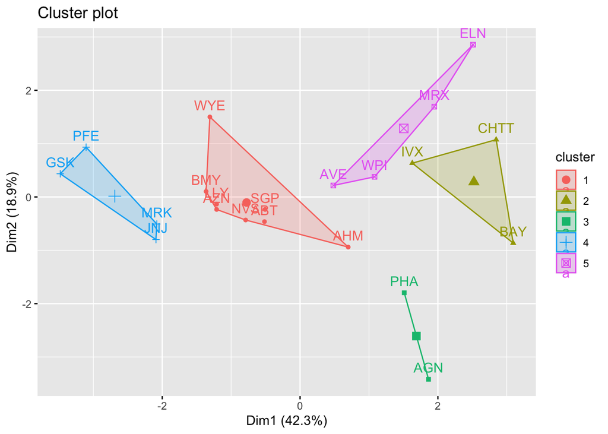

```r
fviz_cluster(k5, data=pharma)
```

### Conduct WSS (Elbow) Method

Now I use the Elbow method to identify the point where adding more clusters stops meaningfully increasing similarities between the firms in each cluster. Here I see a sharp drop at k=2 and a smaller but still distinct bend at k=3, suggesting that these would be the most meaningful numbers of clusters. This aligns with what I observed in the K-Means plots above.

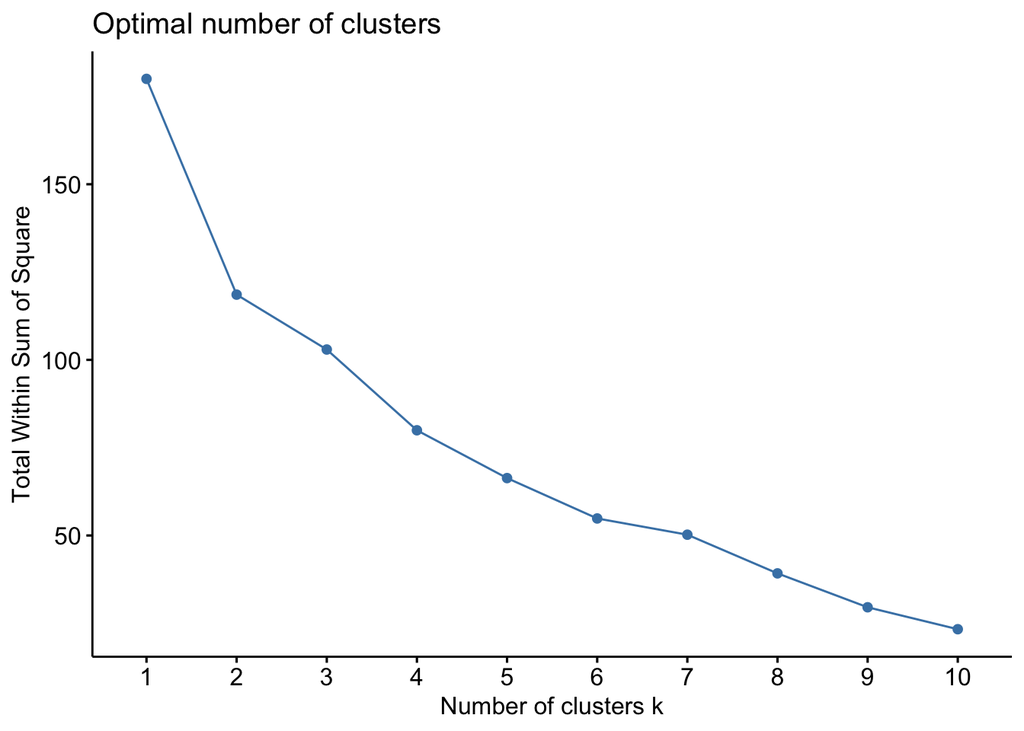

```r
fviz_nbclust(pharma, FUN = kmeans, method = "wss") # Class slides code produced error in gutter; added FUN
```

### Conduct Average Silhouette Method

As one more angle on choosing the best number of clusters, I run the Silhouette method. This method measures how similar each data point is to its own cluster compared with other clusters. In this Silhouette plot, we see that the firms are most closely related to their respective clusters and farthest from the other clusters when grouped into five clusters. However, two clusters come out nearly the same as five, and three is only slightly lower. I’m curious why five clusters emerge above the other numbers of clusters but am encouraged that two and three clusters are once again positive choices.

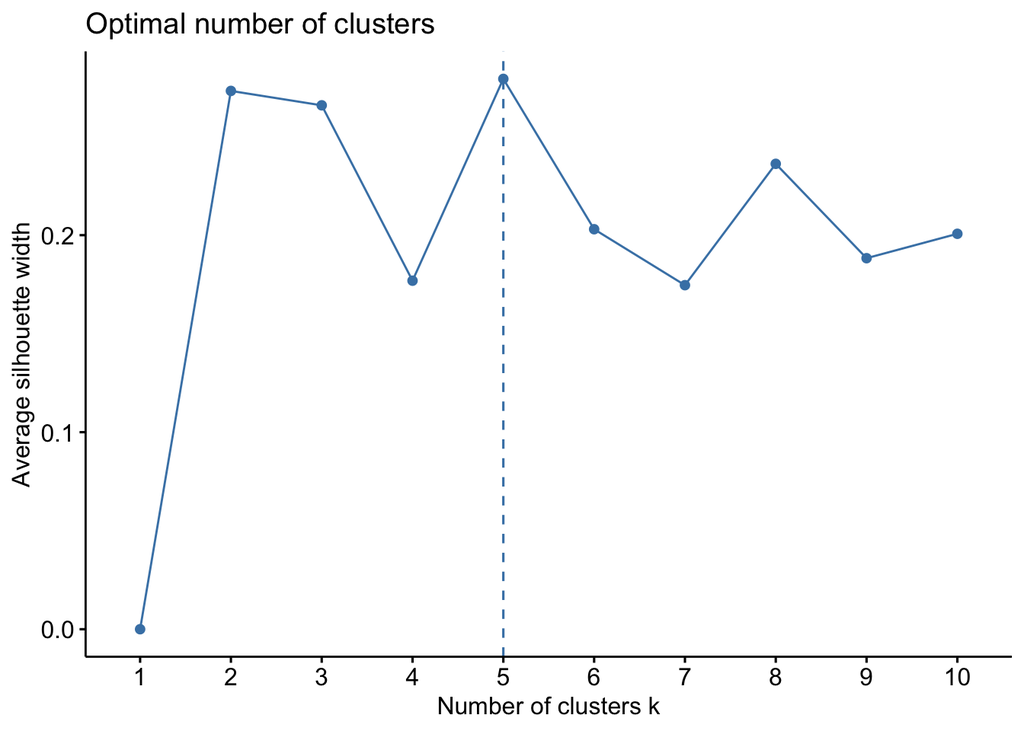

```r
fviz_nbclust(pharma, kmeans, method = "silhouette")
```

## PART B: Interpret the Clusters

### Show Cluster Membership

I want to see which firms were assigned to each cluster to help begin the process of interpreting their similarities. In Data Mining for Business Analytics, Chapter 15, Cluster Analysis, the authors reveal cluster membership with the below function.

```r
k3 <- kmeans(pharma, 3)
k3$cluster
```

```
##  ABT  AGN  AHM  AZN  AVE  BAY  BMY CHTT  ELN  LLY  GSK  IVX  JNJ  MRX  MRK  NVS
##    3    2    2    3    2    1    3    1    1    3    3    1    3    1    3    3
##  PFE  PHA  SGP  WPI  WYE
##    3    2    3    2    3
```

### Profile Plot of Centroids

I want to learn why the firms are clustered the way they are. What commonalities do they have with their cluster neighbors, and what differences do they have with the firms in the other clusters? In Chapter 15, Cluster Analysis, of the Data Mining for Business Analytics textbook, code is given for plotting a visual representation of each cluster’s centroids. Below, I copy and revise the textbook code to fit my setup. (I needed help formatting the chart to fit the length of my variable names.)

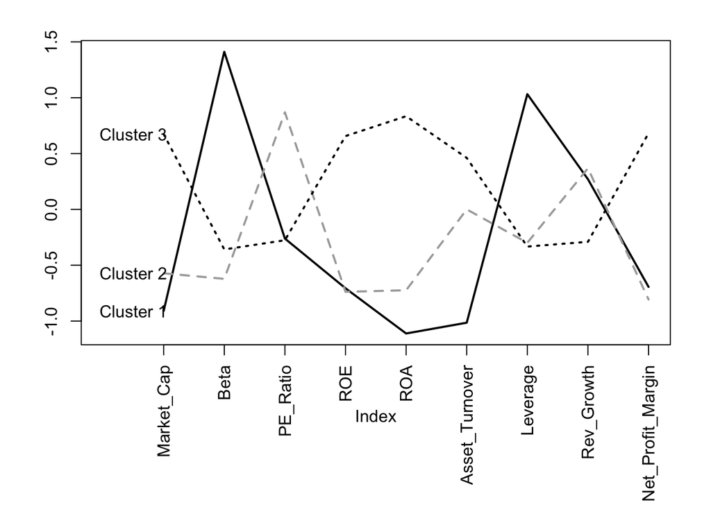

```r
par(mar = c(8, 4, 2, 2))   # enlarge bottom margin

# plot an empty scatter plot
plot(c(0), xaxt = 'n', ylab = "", type = "l",
     ylim = c(min(k3$centers), max(k3$centers)), xlim = c(0, 9)) # 9 variables

# label x-axes
axis(1, at = 1:9, labels = colnames(pharma), las=2) # las = 2 sets the labels vertically

# plot centroids
for (i in 1:3) {
lines(1:9, k3$centers[i,], lty = i, lwd = 2, col = ifelse(i %in% c(1, 3),
                            "black", "darkgrey"))
  }

# name clusters
text(x = 0.5, y = k3$centers[, 1], labels = paste("Cluster", 1:3))
```

### Print Centroids

```r
k3#centroids
```

```
## K-means clustering with 3 clusters of sizes 5, 5, 11
##
## Cluster means:
##   Market_Cap       Beta   PE_Ratio        ROE        ROA Asset_Turnover
## 1 -0.9090570  1.4110965 -0.2613021 -0.7063477 -1.1114156  -1.014784e+00
## 2 -0.5723845 -0.6220844  0.8692748 -0.7381675 -0.7242993  -3.108624e-16
## 3  0.6733825 -0.3586419 -0.2763512  0.6565978  0.8344159   4.612656e-01
##     Leverage Rev_Growth Net_Profit_Margin
## 1  1.0319661  0.2701808        -0.6941793
## 2 -0.2991312  0.3682951        -0.8069490
## 3 -0.3331068 -0.2902163         0.6823310
##
## Clustering vector:
##  ABT  AGN  AHM  AZN  AVE  BAY  BMY CHTT  ELN  LLY  GSK  IVX  JNJ  MRX  MRK  NVS
##    3    2    2    3    2    1    3    1    1    3    3    1    3    1    3    3
##  PFE  PHA  SGP  WPI  WYE
##    3    2    3    2    3
##
## Within cluster sum of squares by cluster:
## [1] 31.94053 22.06946 43.30886
##  (between_SS / total_SS =  45.9 %)
##
## Available components:
##
## [1] "cluster"      "centers"      "totss"        "withinss"     "tot.withinss"
## [6] "betweenss"    "size"         "iter"         "ifault"
```

### Analysis

Here I needed to prompt generative AI to behave as an equities Subject Matter Expert (SME). I requested brief definitions of the variables and their significance to an equities analyst. I reference these brief explanations as I inspect the Centroids. In normal circumstances, I may consult further with a SME while forming an analysis, but as the current “SME” is generative and this is a graded assignment, my relationship here is limited solely to an introductory overview of the terms and their significance. All analysis is my own.

**Cluster 1: Target for Acquisition**

Cluster 1 is comprised of firms that are low market cap (-0.91), high beta (1.41), overleveraged (1.03), and experiencing low return on assets (ROA) (-1.11). All of these factors could be considered negative to a potential investor. Market cap, according to my “SME,” represents the total value of the company based on share price times number of shares. This cluster’s low market cap mean suggests the firms in Cluster 1 are small. Beta measures volatility relative to the market. A beta above one is more volatile than the market. Leverage refers to the ratio of debt to equity or assets. An overleveraged company has too much debt and is at risk of bankruptcy. And ROA refers to the profit generated per dollar of assets. With low ROA, these firms demonstrate deficient operational strategy.

Now, armed with this information from my “SME,” I put on my analyst hat. While an analyst wouldn’t likely advise investment in small, volatile, overleveraged, poorly operated firms, this last factor has me wondering if Cluster 1’s firms have been be more competitively positioned were they operated more efficiently. Perhaps the analyst would present this group as an opportunity for acquisition. Having had poor success compared with the market and facing a risk of bankruptcy, the leadership of these respective firms may welcome an exit plan, even if the bid is lower than they would have otherwise valued their companies. And if one of the primary obstacles to these firms’ success is ineffective operation, a change in leadership could cause a rebound. Acquiring these small firms under the umbrellas of larger, established corporations could also improve performance.

**Cluster 2: Explore Further (Possible Risk-Tolerant or Short Term Investment)**

My main takeaway from observations of Cluster 2 is that the firms contained within it aren’t performing well but aren’t in enough distress to likely sell their companies at a loss. It is possible their lower performance may be due to poor market fit rather than poor leadership. There are a lot of other possibilities in these numbers and I’d likely explore other methods for evaluation before presenting a cohesive analysis. It is possible these firms would be attractive to a risk-tolerant investor, but I need more information.

**Cluster 3: Sound, Long-Term Investment**

Unlike Cluster 1, Cluster 3 has a positive market cap (0.67), lower beta (-0.36), lower leverage (-0.33), and a higher return on assets (ROA) (0.83). In short, these companies are stable and profitable. They would likely be sound long-term investments.

## PART C: Analyze Relationship Between Cluster Patterns and Non-Numeric Variables 10-12

I establish a new data frame for this cluster since my original excluded non-numeric variables.

```r
pharma_c <- read.csv("Pharmaceuticals.csv")
extra_vars <- pharma_c[,10:12]
extra_vars$cluster <- k3$cluster

extra_vars <- mutate(extra_vars, across(1:3, as.factor))

aggregate(extra_vars[,1:3], by = list(cluster = extra_vars$cluster), FUN = summary)
```

[output not shown]

[output cut: 41 more lines]

```r
head(extra_vars)
```

```
##   Rev_Growth Net_Profit_Margin Median_Recommendation cluster
## 1       7.54              16.1          Moderate Buy       3
## 2       9.16               5.5          Moderate Buy       2
## 3       7.05              11.2            Strong Buy       2
## 4         15                18         Moderate Sell       3
## 5      26.81              12.9          Moderate Buy       2
## 6      -3.17               2.6                  Hold       1
```

### Convert and Aggregate

I needed help with this code.

```r
pharma_c   <- read.csv("Pharmaceuticals.csv")
extra_vars <- pharma_c[, 10:12]
extra_vars$cluster <- k3$cluster

# 10 & 11 numeric, 12 categorical
extra_vars$Median_Recommendation <- as.factor(extra_vars$Median_Recommendation)

## Numeric patterns by cluster
num_summary <- aggregate(extra_vars[, 1:2], by = list(cluster = extra_vars$cluster), FUN = mean)
num_summary
```

```
##   cluster Rev_Growth Net_Profit_Margin
## 1       1   16.35600          11.14000
## 2       2   17.44000          10.40000
## 3       3   10.16455          20.17273
```

```r
## Recommendation pattern by cluster
rec_table <- table(extra_vars$cluster, extra_vars$Median_Recommendation)
rec_table
```

```
##
##     Hold Moderate Buy Moderate Sell Strong Buy
##   1    2            2             1          0
##   2    1            2             1          1
##   3    6            3             2          0
```

### Analysis

**Cluster 1**

Analysts mostly recommend Hold or Moderate Buy, with no Strong Buy ratings. This matches my earlier conclusion that Cluster 1 contains weaker or riskier firms. The recommendations suggest general caution from analysts.

**Cluster 2**

Analyst recommendations are distributed across all categories, including one Strong Buy and one Moderate Sell. This aligns with my earlier uncertainty about this cluster. Firms here may have mixed signals or inconsistent performance. This suggests the need for deeper investigation or possibly refining the clustering approach.

**Cluster 3**

Cluster 3 receives mostly Hold and Moderate Buy recommendations, with some Moderate Sell. This supports my assessment that these firms are relatively stable and strong performers, though I may have recommended them too strongly as dependable long-term investments when their performance is only moderate-to-good.

## PART D: Name Each Cluster

I would develop eloquence were I to establish some experience in the industry, but for now, these are concise names that represent my analysis of each cluster.

**Cluster 1: High-Risk**

**Cluster 2: Investigate Further (or Mixed Performance)**

**Cluster 3: Stable Performers**